# Computing Homework 1

Due: Wednesday 11/8 at 11:59pm, Canvas submission (.nb.html file only)

### Honor Pledge

**On my honor, I have neither received nor given any unauthorized assistance on this Homework.**

- SIGNED: 218007361

```r
# Load packages
library(ggplot2)
library(gridExtra)
library(rstan)
library(bayesplot)
```

In this exercise we consider two methods of simulating from the posterior distribution of a Beta-Binomial Bayesian model. The prior distribution is
$$\pi \sim Beta(1,
2),$$
and the data model is
$$y_i \mid
\pi \overset{ind}{\sim} Bin(6, \pi).$$

Two observations are made:
$$\vec{y} =
(y_1, y_2) = (3, 4).$$

Complete the following questions.

## Question 1: analytical posterior (1pt)

Fill in the two blanks with numbers: the analytical posterior for $\pi$ is

$$\pi \mid \vec{y} \sim
Beta(8,7).$$

## Question 2: Posterior simulation in `rstan` (5 pts total)

### 2 - 1. (1pt)

Fill in the code chunk named `model` below, to define the Bayesian model structure in `rstan`. Use the following notation in your definition:

- `Y` for the data vector $\vec y$;
- `pi` for the parameter.

Be sure to specify the data type, range, vector length (if applicable), etc.

```r
the_model <- "
  data {
    int<lower=0, upper=6> Y[2];
  }
  parameters {
    real<lower=0, upper=1> pi;
  }
  model {
    Y ~ binomial(6, pi);
    pi ~ beta(1, 2);
  }
"
```

### 2 - 2. (0pt)

Complete the code below to simulate from the posterior using the model defined above. Use the following settings:

- number of `chains`: 4
- number of `iter`: 10,000.

```r
the_sim <- stan(model_code = the_model, data = list(Y = c(3,4)),
                chains = 4, iter = 10000, seed = 1000)
```

### 2 - 3. (1pt)

Visualize the trace plots of the chains in `the_sim`:

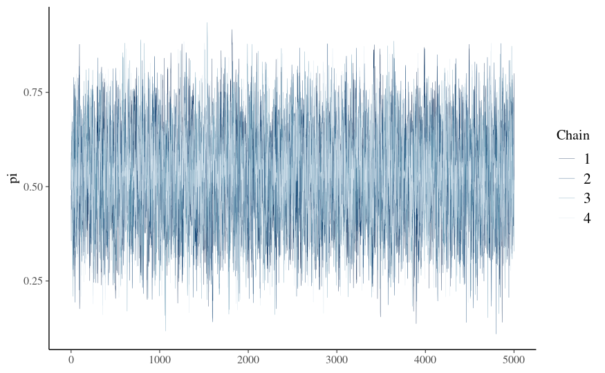

```r
mcmc_trace(the_sim, pars = "pi", size = 0.1)
```

### 2 - 4. (1pt)

Visualize the histogram of the chains in `the_sim`:

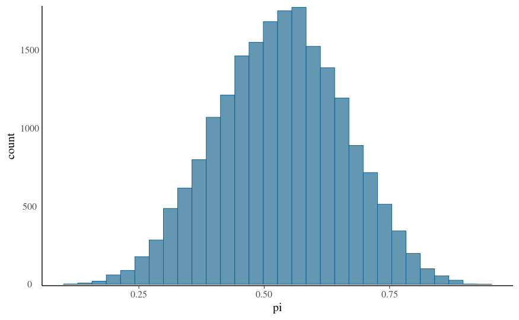

```r
mcmc_hist(the_sim, pars = "pi") +
  yaxis_text(TRUE) + ylab("count")
```

### 2 - 5. (1pt)

Calculate the effective sample size ratio for `the_sim`:

```r
neff_ratio(the_sim, pars = c("pi"))
```

```
[1] 0.3701599
```

- Is this result satisfactory? Yes

### 2 - 6. (1pt)

Calculate the $\hat{R}$ for the chains in `the_sim`:

```r
rhat(the_sim, pars = "pi")
```

```
[1] 1.000401
```

- Is this result satisfactory? Yes

## Question 3: Posterior simulation via Independence Sampler (4 pts total)

Now forget about what you did using `rstan`. Instead, use the Independence Sampler algorithm to target the posterior distribution for $\pi$, **assuming you do not know its analytical distribution**. Use proposal distribution

$$\pi^* \sim Beta(a, b).$$

### 3 - 1. (1pt)

Complete the code chunk below to define the function, `one_iteration`, that produces one iteration of the independent sampler. Here,

- `a`: hyperparameter $a$;
- `b`: hyperparameter $b$;
- `current`: current value of the chain.

```r
one_iteration <- function(a, b, current){
 # STEP 1: Propose the next chain location
 proposal <- rbeta(1, a, b)
 # STEP 2: Decide whether or not to go there
 proposal_plaus <- dbeta(proposal, 1, 2) * dbinom(7, 12, proposal)
 proposal_q     <- dbeta(proposal, a, b)
 current_plaus  <- dbeta(current, 1, 2) * dbinom(7, 12, current)
 current_q      <- dbeta(current, a, b)

 alpha <- min(1, proposal_plaus/current_plaus * current_q/proposal_q)
 next_stop <- sample(c(proposal, current),
                     size = 1, prob = c(alpha, 1-alpha))
 return(data.frame(proposal, alpha, next_stop))
}
```

### 3 - 2. (3 pts)

The function `whole_tour`, which produces `N` iterations of the independence sampler, has been defined for you below.

```r
whole_tour <- function(N, a, b){
  # 1. Start the chain at location 0.5
  current <- 0.5
  # 2. Initialize the simulation
  pi <- rep(0, N)
  # 3. Simulate N Markov chain stops
  for(i in 1:N){
    # Simulate one iteration
    sim <- one_iteration(a = a, b = b, current = current)
    # Record next location
    pi[i] <- sim$next_stop
    # Reset the current location
    current <- sim$next_stop
  }
  # 4. Return the chain locations
  return(data.frame(iteration = c(1:N), pi))
}
```

Complete the following chunks of code to:

- (1pt) Use the `whole_tour` function to produce the object `independence_sim`, consisting of `N = 5000` iterations from the independent sampler, with prior hyperparameters `a = 1` and `b = 2`;

```r
set.seed(1000)
independence_sim <- whole_tour(N=5000, a=1, b=2)
```

- (1pt) Produce the trace plot of the chain in `independence_sim`:

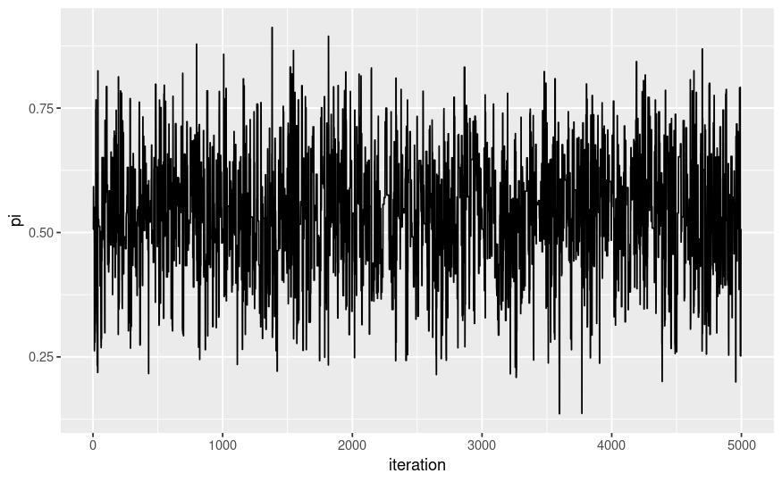

```r
ggplot(independence_sim, aes(x = iteration, y =  pi)) +
  geom_line()
```

- (1pt) Produce the histogram of the chain in `independence_sim`, and overlay it with the analytical posterior for $\pi$ which you derived from Question 1.

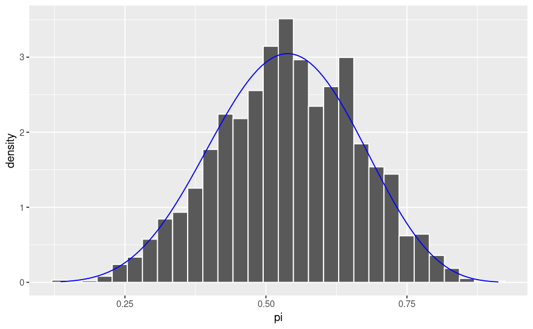

```r
ggplot(independence_sim, aes(x = pi)) +
  geom_histogram(aes(y = ..density..), bins=30, color = "white") +
  stat_function(fun = dbeta, args = list(8,7), color = "blue")
```